# EDA SIP

Whendell Feijó Magalhães

21 de Abril de 2019

```r
library(tidyverse)
library(here)
library(formattable)
source(here::here("code/lib.R"))
theme_set(theme_bw())

knitr::opts_chunk$set(tidy = FALSE,
                      fig.width = 7,
                      fig.height = 6,
                      echo = TRUE,
                      fig.align="center")
```

```r
estimativas_raw = read_projectdata()
```

## O que são os dados

```r
glimpse(estimativas_raw)
```

```
## Observations: 12,299
## Variables: 17
## $ TaskNumber           <chr> "1735", "1742", "1971", "2134", "2251", "...
## $ Summary              <chr> "Flag RI on SCM Message Summary screen us...
## $ Priority             <dbl> 1, 1, 2, 5, 10, 1, 5, 5, 6, 5, 2, 1, 3, 1...
## $ RaisedByID           <chr> "58", "58", "7", "50", "46", "13", "13", ...
## $ AssignedToID         <chr> "58", "42", "58", "42", "13", "13", "13",...
## $ AuthorisedByID       <chr> "6", "6", "6", "6", "6", "58", "6", "6", ...
## $ StatusCode           <chr> "FINISHED", "FINISHED", "FINISHED", "FINI...
## $ ProjectCode          <chr> "PC2", "PC2", "PC2", "PC2", "PC2", "PC9",...
## $ ProjectBreakdownCode <chr> "PBC42", "PBC21", "PBC75", "PBC42", "PBC2...
## $ Category             <chr> "Development", "Development", "Operationa...
## $ SubCategory          <chr> "Enhancement", "Enhancement", "In House S...
## $ HoursEstimate        <dbl> 14.00, 7.00, 0.70, 0.70, 3.50, 7.00, 7.00...
## $ HoursActual          <dbl> 1.75, 7.00, 0.70, 0.70, 3.50, 7.00, 7.00,...
## $ DeveloperID          <chr> "58", "42", "58", "42", "13", "13", "43",...
## $ DeveloperHoursActual <dbl> 1.75, 7.00, 0.70, 0.70, 3.50, 7.00, 7.00,...
## $ TaskPerformance      <dbl> 12.25, 0.00, 0.00, 0.00, 0.00, 0.00, 0.00...
## $ DeveloperPerformance <dbl> 12.25, 0.00, 0.00, 0.00, 0.00, 0.00, NA, ...
```

## Entendendo os dados

```r
estimativas_raw %>%
    select(ProjectCode, TaskNumber, HoursEstimate, HoursActual) %>%
    skimr::skim()
```

```
## Skim summary statistics
##  n obs: 12299
##  n variables: 4
##
## ── Variable type:character ─────────────────────────────────────────────────────────────────────────────────────────────────────
##     variable missing complete     n min max empty n_unique
##  ProjectCode       0    12299 12299   3   4     0       20
##   TaskNumber       0    12299 12299   4   5     0    10266
##
## ── Variable type:numeric ───────────────────────────────────────────────────────────────────────────────────────────────────────
##       variable missing complete     n  mean    sd   p0 p25 p50 p75    p100
##    HoursActual       0    12299 12299 13.18 68.72 0.01   1   3 8.5 2490.16
##  HoursEstimate       0    12299 12299 10.15 28.84 0.01   1   3 7    910
##      hist
##  ▇▁▁▁▁▁▁▁
##  ▇▁▁▁▁▁▁▁
```

Temos 20 projetos, com 12299 estimativas_raw. Não há apenas uma estimativa por tarefa, já que há apenas 10266 valores distintos de `TaskNumber`.

### 1 estimativa por task

Para nossa análise, usaremos uma estimativa por task. Caso haja mais de uma usaremos a média das estimativas_raw:

```r
estimativas = estimativas_raw %>%
    group_by(ProjectCode, TaskNumber, Category, Priority, Summary) %>%
    summarise(
        HoursEstimate = mean(HoursEstimate),
        HoursActual = mean(HoursActual),
        DeveloperPerformance = mean(DeveloperPerformance)
    ) %>%
    ungroup()
```

### Dados por time

```r
por_time <- estimativas_raw %>%
    group_by(ProjectCode) %>%
    summarise(devs = NROW(unique(DeveloperID)),
              erro_medio_abs = mean(abs(HoursEstimate - HoursActual)),
              estimativas = n())

formattable(por_time)
```

| ProjectCode | devs | erro_medio_abs | estimativas |
| --- | --- | --- | --- |
| PC1 | 4 | 18.514444 | 54 |
| PC10 | 4 | 35.907123 | 73 |
| PC11 | 11 | 4.604863 | 292 |
| PC12 | 3 | 8.271852 | 54 |
| PC13 | 6 | 8.500351 | 171 |
| PC14 | 11 | 90.409429 | 105 |
| PC15 | 3 | 1.866667 | 3 |
| PC16 | 8 | 9.592105 | 114 |
| PC17 | 10 | 14.981537 | 449 |
| PC18 | 15 | 14.163224 | 2888 |
| PC19 | 1 | 3.896341 | 41 |
| PC2 | 16 | 4.150092 | 4553 |
| PC20 | 2 | 98.684000 | 5 |
| PC3 | 5 | 5.033218 | 87 |
| PC4 | 8 | 4.953268 | 511 |
| PC5 | 8 | 12.230494 | 648 |
| PC6 | 6 | 10.708537 | 287 |
| PC7 | 10 | 10.787793 | 145 |
| PC8 | 11 | 6.071094 | 64 |
| PC9 | 14 | 11.912057 | 1755 |

### Qual a relação entre as estimativas e horas reais tomadas na empresa como um todo?

#### Antes de realizar qualquer operação/modificação nos dados preprocessados, plotei um gráfico de pontos com as variáveis de interesse com a finalidade de analisar a dispersão dos dados e tentar encontrar valores extremos ou errados. Como pode ser visto no gráfico abaixo a maior concentração dos dados está no intervalo de [0,250] para a variável HoursEstimate e [0,500] para a variável HoursActual. Além disso também é possível identificar valores extremos que ocorrem quando há uma discrepância muito grande entre as horas estimadas e as reais.

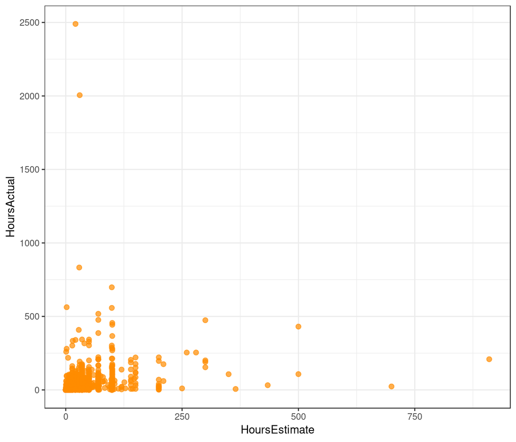

```r
estimativas %>%
    ggplot(aes(x = HoursEstimate, y = HoursActual)) +
    geom_point(color = "darkorange", size = 2, alpha = 0.7)
```

### A tabela abaixo nos mostra quem são esses pontos extremos:

```r
estimativas %>%
    filter(HoursActual > 1000 | HoursEstimate >= 500) %>%
    select(TaskNumber, HoursEstimate, HoursActual) %>%
    mutate("Actual - Estimate" = HoursActual - HoursEstimate) %>%
    formattable()
```

| TaskNumber | HoursEstimate | HoursActual | Actual - Estimate |
| --- | --- | --- | --- |
| 13505 | 700 | 23.50 | -676.50 |
| 12159 | 30 | 2005.30 | 1975.30 |
| 11148 | 21 | 2490.16 | 2469.16 |
| 6901 | 500 | 107.50 | -392.50 |
| 12816 | 910 | 208.86 | -701.14 |
| 6266 | 500 | 430.79 | -69.21 |

#### A coluna ‘Actual - Estimate’ foi adicionada para facilitar a identificação da diferença entre a estimativa e o tempo real. *Valores positivos* indicam que o *tempo real* foi superior ao estimado em *n* horas e *valores negativos* indicam que o *tempo estimado* foi superior ao real em *n* horas.

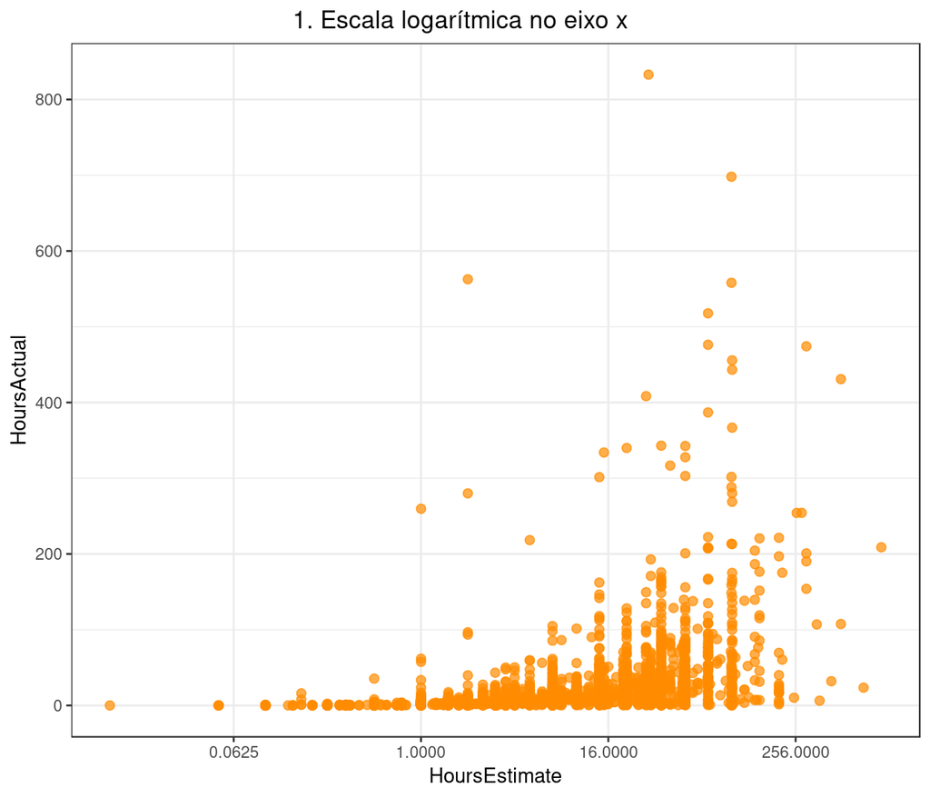

```r
estimativas <- filter(estimativas, HoursActual < 1000)

estimativas %>%
    ggplot(aes(x = HoursEstimate, y = HoursActual)) +
    geom_point(color = "darkorange", size = 2, alpha = 0.7) +
    scale_x_continuous(trans='log2', minor_breaks = F) +
    ggtitle("\t\t\t\t1. Escala logarítmica no eixo x")
```

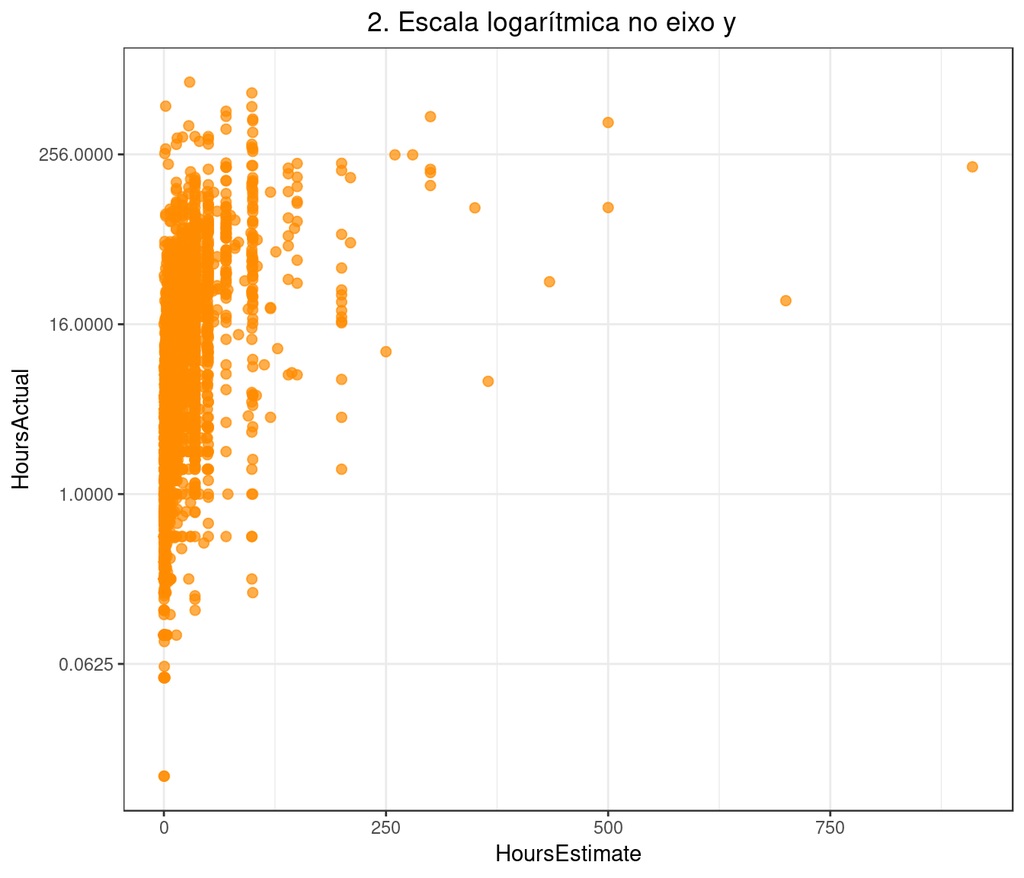

```r
estimativas %>%
    ggplot(aes(x = HoursEstimate, y = HoursActual)) +
    geom_point(color = "darkorange", size = 2, alpha = 0.7) +
    scale_y_continuous(trans='log2', minor_breaks = F) +
    ggtitle("\t\t\t\t2. Escala logarítmica no eixo y")
```

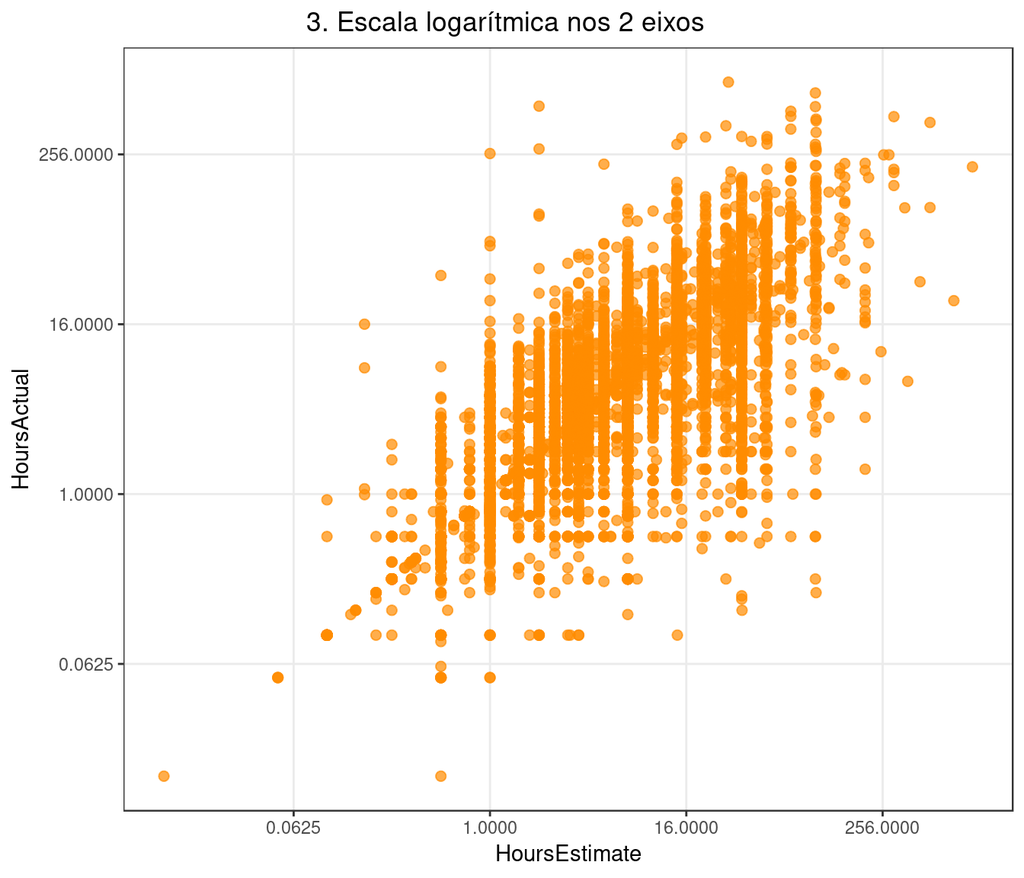

```r
estimativas %>%
    ggplot(aes(x = HoursEstimate, y = HoursActual)) +
    geom_point(color = "darkorange", size = 2, alpha = 0.7) +
    scale_y_continuous(trans='log2', minor_breaks = F) +
    scale_x_continuous(trans='log2', minor_breaks = F) +
    ggtitle("\t\t\t3. Escala logarítmica nos 2 eixos")
```

#### Os gráficos acima mostram a dispersão quando aplicamos uma transformação logarítmica nos eixos. Ao aplicar a transformação no eixo x já é possível identificar que há uma correlação positiva entre as variáveis, isso fica ainda mais evidente quando aplicamos a mesma transformação em ambos os eixos, indicando que há uma relação polinomial positiva entre as variáveis HoursEstimate e HoursActual. A tabela abaixo representa os coeficientes de correlação:

```r
estimativas %>%
    summarise(pearson = cor(HoursEstimate, HoursActual, method = "pearson"),
            spearman = cor(HoursEstimate, HoursActual, method = "spearman"),
            kendall = cor(HoursEstimate, HoursActual, method = "kendall")) %>%
    formattable()
```

| pearson | spearman | kendall |
| --- | --- | --- |
| 0.4632568 | 0.8259756 | 0.6958377 |

### Qual a relação entre as estimativas e horas reais em diferentes categorias de tarefa?

#### O gráfico abaixo mostra a dispersão da variável HoursActual em função da variável HoursEstimate por categoria de tarefa. Visto que esses dados são um subconjunto dos anteriormente explorados os pontos extremos são os mesmos.

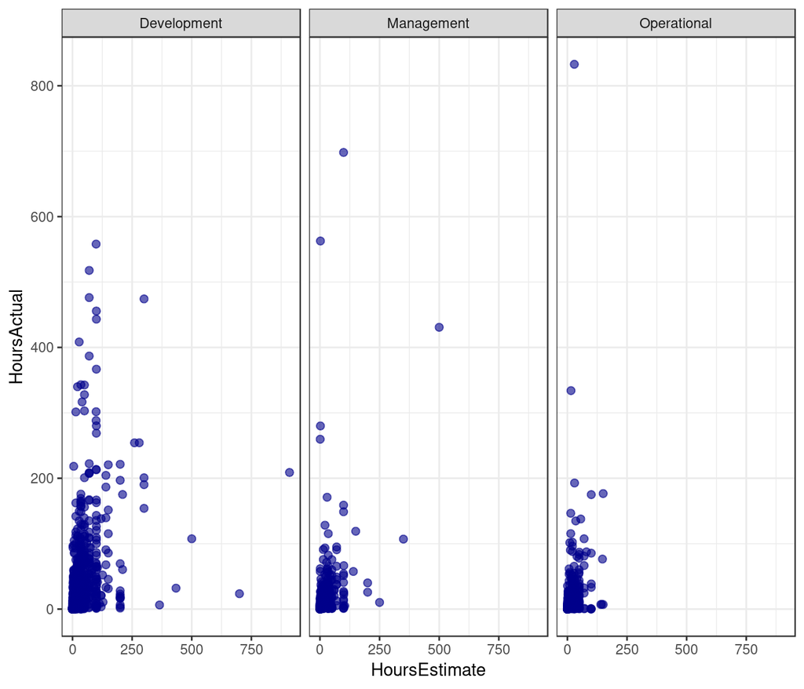

```r
estimativas %>%
    ggplot(aes(x = HoursEstimate, y = HoursActual)) +
    geom_point(color = "darkblue", size = 2, alpha=0.6) +
    facet_wrap(~Category)
```

#### Nos gráficos, que apresenta relação dos dados ao aplicar transformações logarítmicas em cada um dos eixos e em ambos simulataneamente, podemos observar uma tendência parecida com a apresentada pelos dados da empresa como um todo, tanto em forma quanto em sinal e força.

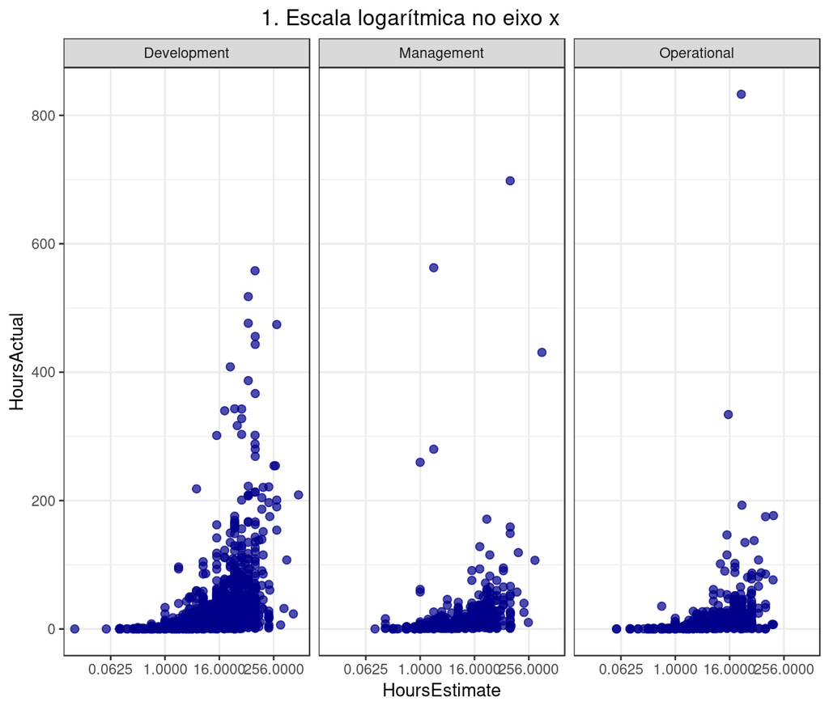

```r
estimativas %>%
    ggplot(aes(x = HoursEstimate, y = HoursActual)) +
    geom_point(color = "darkblue", size = 2, alpha = 0.7) +
    scale_x_continuous(trans='log2', minor_breaks = F) +
    ggtitle("\t\t\t\t1. Escala logarítmica no eixo x") +
    facet_wrap(~Category)
```

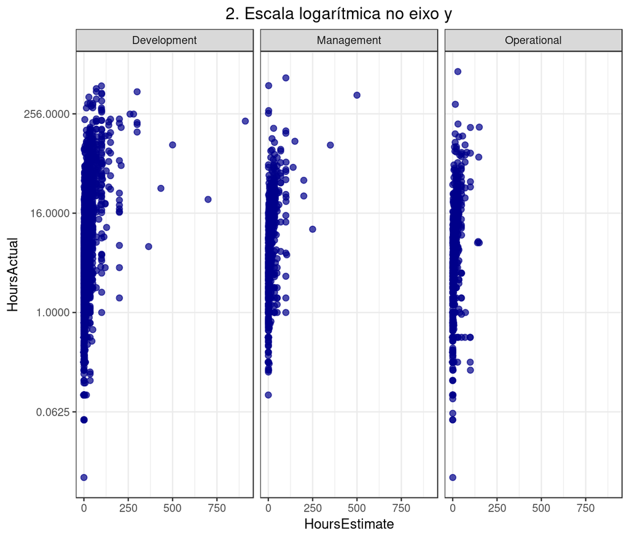

```r
estimativas %>%
    ggplot(aes(x = HoursEstimate, y = HoursActual)) +
    geom_point(color = "darkblue", size = 2, alpha = 0.7) +
    scale_y_continuous(trans='log2', minor_breaks = F) +
    ggtitle("\t\t\t\t2. Escala logarítmica no eixo y") +
    facet_wrap(~Category)
```

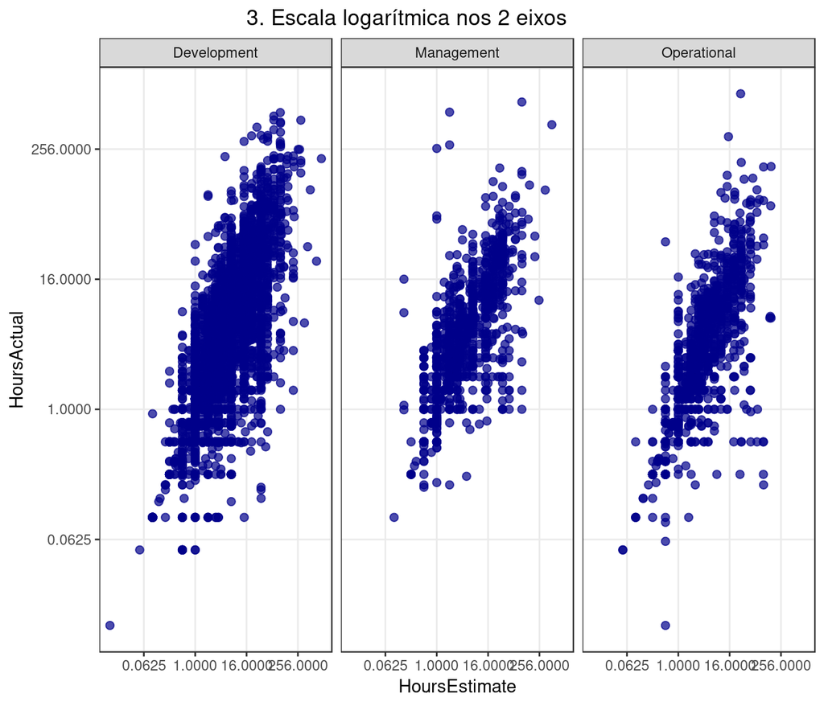

```r
estimativas %>%
    ggplot(aes(x = HoursEstimate, y = HoursActual)) +
    geom_point(color = "darkblue", size = 2, alpha = 0.7) +
    scale_y_continuous(trans='log2', minor_breaks = F) +
    scale_x_continuous(trans='log2', minor_breaks = F) +
    ggtitle("\t\t\t3. Escala logarítmica nos 2 eixos") +
    facet_wrap(~Category)
```

#### A tabela abaixo apresenta os coeficientes de correlação por categoria:

```r
estimativas %>%
    group_by(Category) %>%
    summarise(pearson = cor(HoursEstimate, HoursActual, method = "pearson"),
            spearman = cor(HoursEstimate, HoursActual, method = "spearman"),
            kendall = cor(HoursEstimate, HoursActual, method = "kendall")) %>%
    formattable()
```

| Category | pearson | spearman | kendall |
| --- | --- | --- | --- |
| Development | 0.4863568 | 0.8344993 | 0.7001966 |
| Management | 0.4555045 | 0.7528142 | 0.6348328 |
| Operational | 0.3421127 | 0.8415121 | 0.7290575 |

### Equipes com mais desenvolvedores produzem estimativas com mais ou menos erro que equipes menores?

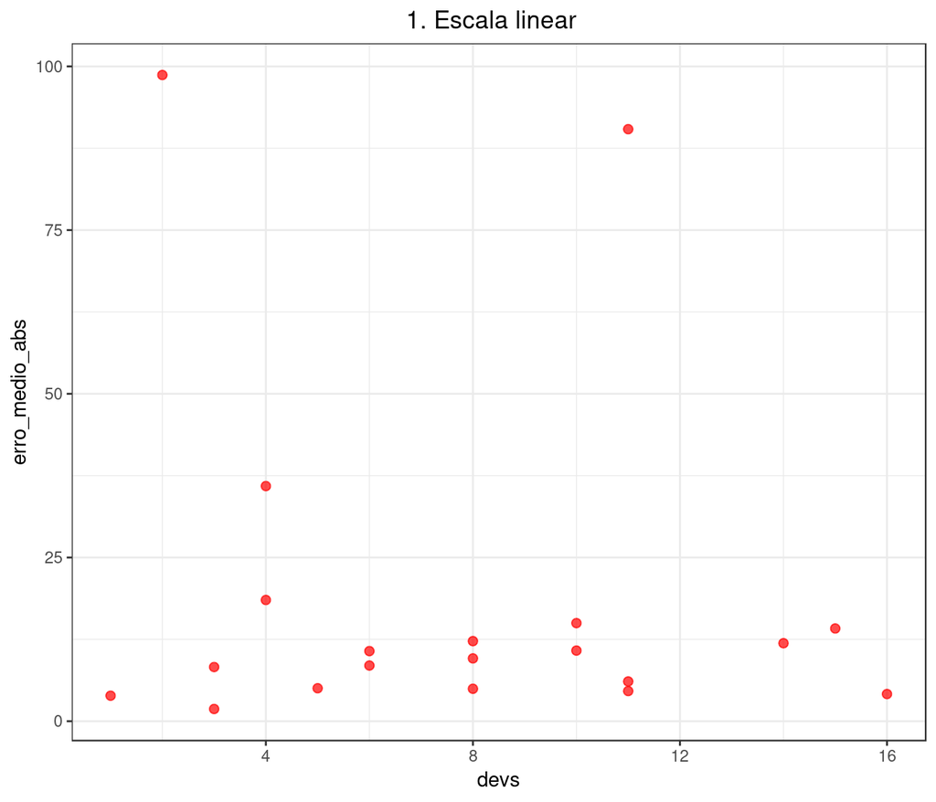

```r
por_time %>%
    ggplot(aes(x = devs, y = erro_medio_abs)) +
    geom_point(color = "red", size = 2, alpha = 0.7) +
    ggtitle("\t\t\t\t\t\t1. Escala linear")
```

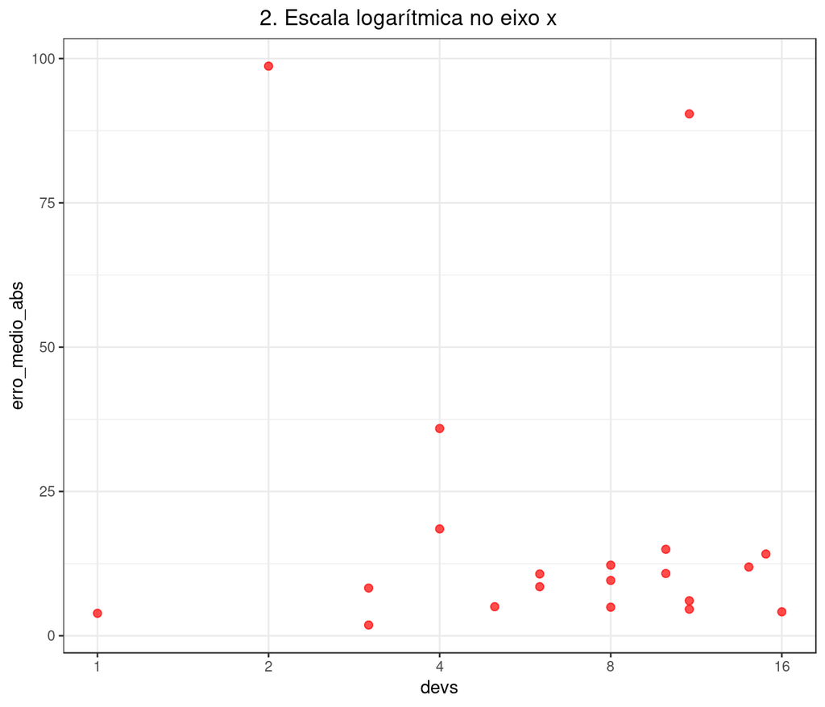

```r
por_time %>%
    ggplot(aes(x = devs, y = erro_medio_abs)) +
    geom_point(color = "red", size = 2, alpha = 0.7) +
    scale_x_continuous(trans='log2', minor_breaks = F) +
    ggtitle("\t\t\t\t2. Escala logarítmica no eixo x")
```

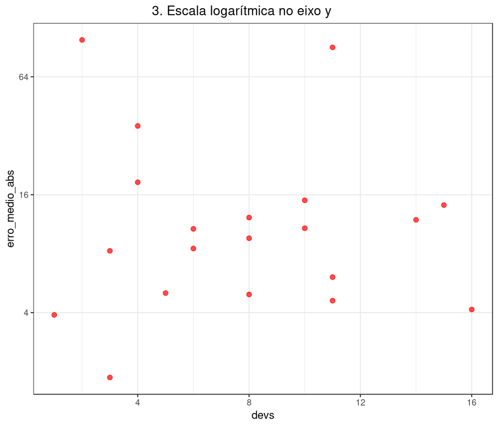

```r
por_time %>%
    ggplot(aes(x = devs, y = erro_medio_abs)) +
    geom_point(color = "red", size = 2, alpha = 0.7) +
    scale_y_continuous(trans='log2', minor_breaks = F) +
    ggtitle("\t\t\t\t3. Escala logarítmica no eixo y")
```

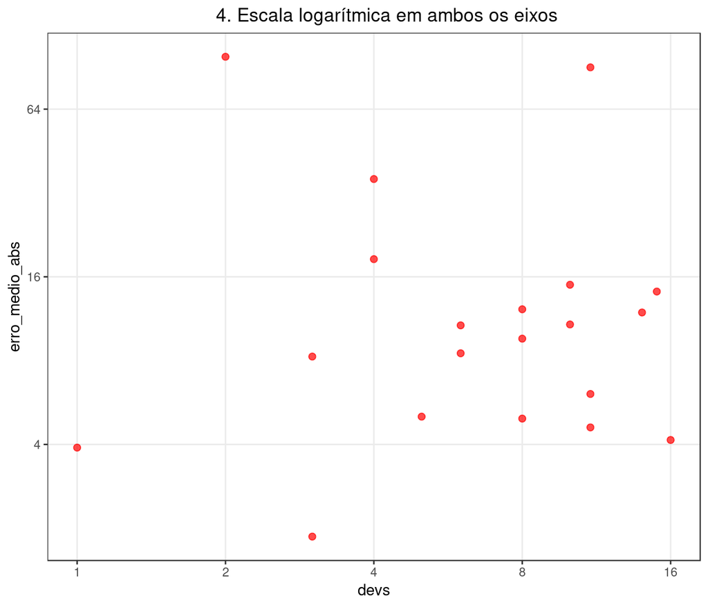

```r
por_time %>%
    ggplot(aes(x = devs, y = erro_medio_abs)) +
    geom_point(color = "red", size = 2, alpha = 0.7) +
    scale_x_continuous(trans='log2', minor_breaks = F) +
    scale_y_continuous(trans='log2', minor_breaks = F) +
    ggtitle("\t\t\t\t4. Escala logarítmica em ambos os eixos")
```

#### Os gráficos acima mostram a distribuição do erro médio absoluto por tarefa em função do número de desenvolvedores por equipe. A partir da vizualização é difícil identificar uma correlação entre o número de desenvolvedores e o erro médio na estimativa, ainda que apliquemos transformações logarítmicas nos eixos, o que me leva a conclusão de que as variáveis não apresentam relação entre si. Os coeficientes apresentados na tabela abaixo são mais uma evidência de que estas variáveis não são correlacionadas.

```r
por_time %>%
    summarise(pearson = cor(devs, erro_medio_abs, method = "pearson"),
              spearman = cor(devs, erro_medio_abs, method = "spearman"),
              kendall = cor(devs, erro_medio_abs, method = "kendall")) %>%
    formattable()
```

| pearson | spearman | kendall |
| --- | --- | --- |
| -0.1365125 | 0.0438071 | 0.03244428 |